# XGBoost

Author

Dante Conti, Sergi Ramirez, (c) IDEAI

# 1 Descripción del problema

En este documento se estudia el algoritmo **XGBoost** aplicado a un problema de **clasificación supervisada multiclase**. El objetivo será predecir el nivel de renta del entorno de una vivienda de Barcelona (`RENTA`) a partir de características del inmueble, del edificio y de su localización.

La base de datos procede de anuncios de vivienda de Idealista y se ha enriquecido con información de renta media por hogar/persona a nivel de sección censal. A partir de la renta media por hogar se construye una variable categórica de tres niveles:

- **Baja**: renta media por hogar inferior a 30.000 €.
- **Media**: renta media por hogar entre 30.000 € y 50.000 €.
- **Alta**: renta media por hogar superior a 50.000 €.

Por tanto, el problema se puede formular como:

$$Y = f(X_1, X_2, \ldots, X_p) + \varepsilon$$

donde:

- $Y$ es la variable objetivo `RENTA`.
- $X_1, X_2, \ldots, X_p$ son las variables explicativas.
- $f$ es una función no lineal aprendida mediante una suma secuencial de árboles.

XGBoost no construye un único árbol, ni muchos árboles independientes como Random Forest. XGBoost construye árboles de forma **secuencial**: cada nuevo árbol intenta corregir los errores cometidos por el conjunto de árboles anterior.

# 2 Introducción teórica a XGBoost

## 2.1 De árboles individuales a boosting

Un árbol de decisión aprende reglas del tipo:

> Si `CDIS = Sarrià-Sant Gervasi` y `DISTANCE_TO_CITY_CENTER < 3`, entonces la renta probablemente es `Alta`.

Un único árbol suele ser fácil de interpretar, pero puede ser inestable. Random Forest reduce esa inestabilidad entrenando muchos árboles en paralelo y agregando sus votos. XGBoost usa otra lógica: entrena árboles pequeños de forma secuencial, donde cada árbol nuevo se concentra en los errores que todavía quedan por corregir.

La predicción final se expresa como una suma de árboles:

$$\hat{y}_i = \sum_{m=1}^{M} \eta f_m(x_i)$$

donde:

- $M$ es el número de árboles.
- $f_m$ es el árbol añadido en la iteración $m$.
- $\eta$ es la tasa de aprendizaje o `learning_rate`.
- $x_i$ representa las variables explicativas del individuo $i$.

La idea básica es:

1. Se empieza con una predicción inicial.
2. Se calcula el error del modelo.
3. Se entrena un nuevo árbol para reducir ese error.
4. Se añade el árbol al modelo con un peso pequeño.
5. Se repite el proceso muchas veces.

## 2.2 Diferencia entre Random Forest y XGBoost

| Aspecto | Random Forest | XGBoost |
| --- | --- | --- |
| Construcción de árboles | Paralela | Secuencial |
| Objetivo de cada árbol | Votar de forma independiente | Corregir errores anteriores |
| Tipo de ensamble | Bagging | Boosting |
| Control del sobreajuste | Promedio de muchos árboles | Regularización, shrinkage, profundidad, submuestreo |
| Interpretabilidad | Importancia de variables y árboles individuales | Importancia, árboles individuales y SHAP |
| Riesgo principal | Puede ser menos preciso si la señal es compleja | Puede sobreajustar si se ajusta mal |

## 2.3 Función objetivo de XGBoost

XGBoost optimiza una función objetivo formada por dos partes:

$$Obj = \sum_{i=1}^{n} L(y_i, \hat{y}_i) + \sum_{m=1}^{M} \Omega(f_m)$$

La primera parte mide el error de predicción:

$$\sum_{i=1}^{n} L(y_i, \hat{y}_i)$$

La segunda parte penaliza la complejidad de los árboles:

$$\sum_{m=1}^{M} \Omega(f_m)$$

Esto es muy importante porque XGBoost no solo intenta ajustar bien los datos, sino que también intenta evitar árboles excesivamente complejos.

Una forma habitual de escribir la penalización de complejidad es:

$$\Omega(f) = \gamma T + \frac{1}{2}\lambda \sum_{j=1}^{T} w_j^2$$

donde:

- $T$ es el número de hojas del árbol.
- $w_j$ es el peso asignado a la hoja $j$.
- $\gamma$ penaliza crear nuevas hojas.
- $\lambda$ penaliza pesos demasiado grandes.

## 2.4 Parámetros principales

Los parámetros más importantes que se usarán durante el documento son:

- `nrounds` / `n_estimators`: número de árboles.
- `eta` / `learning_rate`: peso de cada árbol nuevo.
- `max_depth`: profundidad máxima de cada árbol.
- `subsample`: proporción de observaciones usadas en cada iteración.
- `colsample_bytree`: proporción de variables usadas por árbol.
- `lambda` / `reg_lambda`: regularización L2.
- `alpha` / `reg_alpha`: regularización L1.
- `objective`: función de pérdida que se quiere optimizar.
- `eval_metric`: métrica usada para monitorizar el entrenamiento.

## 2.5 Ventajas principales

XGBoost es uno de los algoritmos más utilizados en problemas tabulares porque:

- captura no linealidades;
- captura interacciones entre variables;
- suele dar muy buen rendimiento predictivo;
- permite regularizar el modelo;
- permite hacer validación temprana mediante `early_stopping`;
- ofrece medidas de importancia de variables;
- permite extraer árboles concretos del modelo;
- se integra muy bien con SHAP para interpretación local y global.

## 2.6 Limitaciones

También tiene limitaciones:

- requiere más ajuste de hiperparámetros que un árbol simple;
- puede sobreajustar si se usan demasiados árboles o árboles muy profundos;
- necesita codificar variables categóricas si se usa una matriz numérica clásica;
- es menos interpretable que un árbol individual;
- su interpretación mediante importancia de variables puede depender de la métrica usada: `gain`, `cover`, `frequency`, etc.

# 3 Carga de datos

El siguiente bloque carga la misma base de datos usada en los ejemplos de árboles y Random Forest.

**Mostrar código**

```r
path <- 'https://raw.githubusercontent.com/ramIA-lab/MLforEducation/refs/heads/main/material/trees_ensambleMethods/idealista18_BCN_conRenta.csv'
BCN <- read.csv2(path)
```

**Mostrar código**

```r
paquetes_necesarios <- c(
  "dplyr", "tidyr", "ggplot2", "caret", "xgboost", "pdp"
)

paquetes_faltantes <- paquetes_necesarios[
  !vapply(paquetes_necesarios, requireNamespace, logical(1), quietly = TRUE)
]

if (length(paquetes_faltantes) > 0) {
  install.packages(paquetes_faltantes, repos = "https://cloud.r-project.org")
}

invisible(lapply(paquetes_necesarios, library, character.only = TRUE))
```

**Mostrar código**

```python
import importlib.util
import subprocess
import sys

paquetes_python = {
    "pandas": "pandas",
    "numpy": "numpy",
    "sklearn": "scikit-learn",
    "xgboost": "xgboost",
    "matplotlib": "matplotlib",
    "shap": "shap"
}

for modulo, paquete in paquetes_python.items():
    if importlib.util.find_spec(modulo) is None:
        subprocess.check_call([sys.executable, "-m", "pip", "install", paquete])
```

# 4 Preprocesamiento de los datos

El preprocesamiento tiene cuatro objetivos:

1. eliminar identificadores, geometrías y columnas que no se usarán como predictores;
2. transformar variables binarias de 0/1 a etiquetas interpretables;
3. crear la variable objetivo `RENTA`;
4. preparar una matriz numérica, porque XGBoost trabaja de forma natural con matrices numéricas.

**Mostrar código**

```r
columnas_a_eliminar <- c(
  "X", "PRICE", "LONGITUDE", "LATITUDE", "geometry", "CONSTRUCTIONYEAR",
  "ASSETID", "PERIOD", "CUSEC", "CSEC", "CMUN", "CPRO", "CCA", "CUDIS",
  "CLAU2", "NPRO", "NCA", "CNUT0", "CNUT1", "CNUT2", "CNUT3", "NMUN",
  "Shape_Leng", "Shape_Area", "CUMUN", "CADASTRALQUALITYID"
)

BCN <- BCN %>%
  select(-any_of(columnas_a_eliminar)) %>%
  mutate(
    across(
      .cols = matches("^(HAS|IS)"),
      .fns = ~ case_when(
        . == 0 ~ "No",
        . == 1 ~ "Si",
        TRUE ~ as.character(.)
      ),
      .names = "{.col}"
    ),
    AMENITYID = case_when(
      AMENITYID == 1 ~ "SinMuebleSinCocina",
      AMENITYID == 2 ~ "CocinaSinMuebles",
      AMENITYID == 3 ~ "CocinaMuebles",
      TRUE ~ "noInfo"
    ),
    FLATLOCATIONID = case_when(
      FLATLOCATIONID == 1 ~ "exterior",
      FLATLOCATIONID == 2 ~ "interior",
      TRUE ~ "noInfo"
    ),
    BUILTTYPEID_1 = case_when(
      BUILTTYPEID_1 == 0 ~ "noObraNueva",
      BUILTTYPEID_1 == 1 ~ "obraNueva",
      TRUE ~ "noInfo"
    ),
    BUILTTYPEID_2 = case_when(
      BUILTTYPEID_2 == 0 ~ "noRestaurar",
      BUILTTYPEID_2 == 1 ~ "Restaurar",
      TRUE ~ "noInfo"
    ),
    BUILTTYPEID_3 = case_when(
      BUILTTYPEID_3 == 0 ~ "noSegundaMano",
      BUILTTYPEID_3 == 1 ~ "SegundaMano",
      TRUE ~ "noInfo"
    ),
    FLOORCLEAN = replace_na(FLOORCLEAN, 0),
    CDIS = case_when(
      CDIS == 1 ~ "Ciutat-Vella",
      CDIS == 2 ~ "Eixample",
      CDIS == 3 ~ "Sants-Montjuic",
      CDIS == 4 ~ "Les Corts",
      CDIS == 5 ~ "Sarrià-Sant Gervasi",
      CDIS == 6 ~ "Gràcia",
      CDIS == 7 ~ "Horta-Guinardó",
      CDIS == 8 ~ "Nou Barris",
      CDIS == 9 ~ "Sant Andreu",
      CDIS == 10 ~ "Sant Martí",
      TRUE ~ "noInfo"
    ),
    RENTA = case_when(
      Renta.media.por.hogar < 30000 ~ "Baja",
      Renta.media.por.hogar >= 30000 & Renta.media.por.hogar <= 50000 ~ "Media",
      Renta.media.por.hogar > 50000 ~ "Alta",
      TRUE ~ NA_character_
    )
  ) %>%
  select(-any_of(c("Renta.media.por.hogar", "Renta.media.por.persona"))) %>%
  mutate(RENTA = factor(RENTA, levels = c("Baja", "Media", "Alta"))) %>%
  na.omit()
```

# 5 Análisis descriptivo

Antes de entrenar un modelo de boosting conviene revisar la variable objetivo y algunas variables explicativas. En clasificación multiclase es especialmente importante mirar si las clases están equilibradas.

**Mostrar código**

```r
dim(BCN)
```

```
[1] 23334    36
```

**Mostrar código**

```r
str(BCN)
```

```
'data.frame':   23334 obs. of  36 variables:
 $ UNITPRICE                    : num  5232 4108 4056 6585 4200 ...
 $ CONSTRUCTEDAREA              : int  56 74 72 65 70 33 82 98 86 94 ...
 $ ROOMNUMBER                   : int  1 2 3 1 3 1 2 3 3 3 ...
 $ BATHNUMBER                   : int  1 1 1 2 1 1 2 1 1 1 ...
 $ HASTERRACE                   : chr  "No" "Si" "No" "Si" ...
 $ HASLIFT                      : chr  "Si" "Si" "Si" "No" ...
 $ HASAIRCONDITIONING           : chr  "No" "No" "No" "Si" ...
 $ AMENITYID                    : chr  "CocinaSinMuebles" "CocinaMuebles" "CocinaMuebles" "CocinaMuebles" ...
 $ HASPARKINGSPACE              : chr  "No" "No" "No" "No" ...
 $ ISPARKINGSPACEINCLUDEDINPRICE: chr  "No" "No" "No" "No" ...
 $ PARKINGSPACEPRICE            : num  1 1 1 1 1 1 1 1 1 1 ...
 $ HASNORTHORIENTATION          : chr  "No" "No" "No" "No" ...
 $ HASSOUTHORIENTATION          : chr  "No" "No" "No" "No" ...
 $ HASEASTORIENTATION           : chr  "No" "No" "No" "No" ...
```

[output cut: 22 more lines]

**Mostrar código**

```r
table(BCN$RENTA)
```

```
 Baja Media  Alta
 7749 13177  2408
```

**Mostrar código**

```r
prop.table(table(BCN$RENTA))
```

```
     Baja     Media      Alta
0.3320905 0.5647124 0.1031971
```

**Mostrar código**

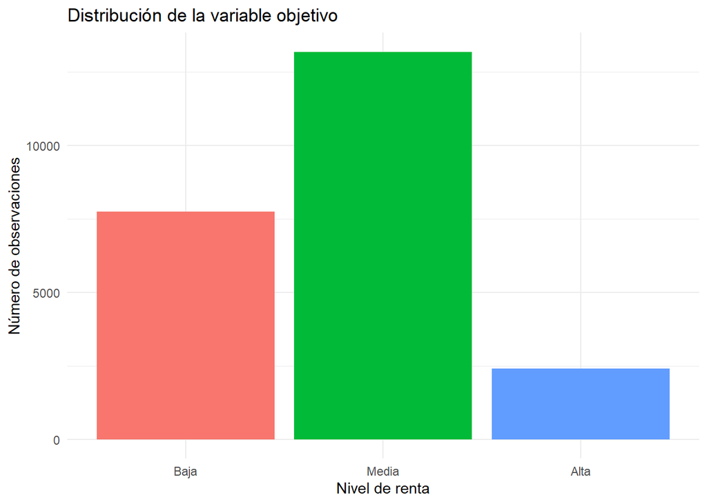

```r
ggplot(BCN, aes(x = RENTA, fill = RENTA)) +
  geom_bar(show.legend = FALSE) +
  labs(
    title = "Distribución de la variable objetivo",
    x = "Nivel de renta",
    y = "Número de observaciones"
  ) +
  theme_minimal()
```

**Mostrar código**

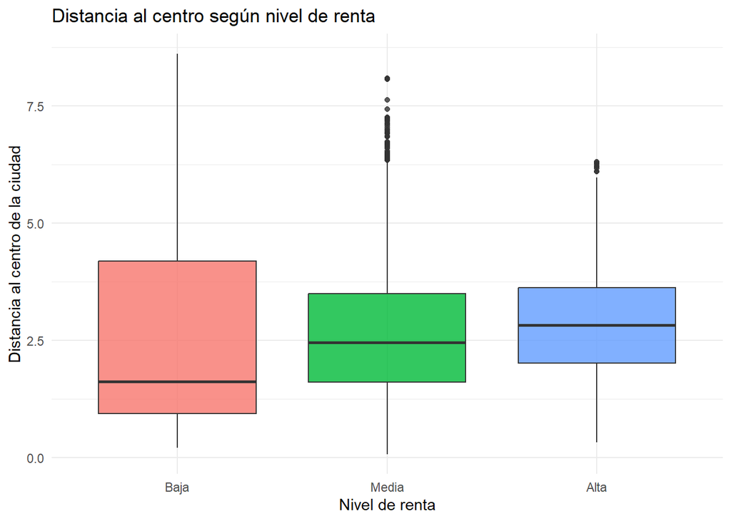

```r
ggplot(BCN, aes(x = RENTA, y = DISTANCE_TO_CITY_CENTER, fill = RENTA)) +
  geom_boxplot(show.legend = FALSE, alpha = 0.8) +
  labs(
    title = "Distancia al centro según nivel de renta",
    x = "Nivel de renta",
    y = "Distancia al centro de la ciudad"
  ) +
  theme_minimal()
```

# 6 Separación entrenamiento/test

Separamos los datos en entrenamiento y test de forma estratificada.

**R**

**Mostrar código**

```r
library(dplyr)

set.seed(1994)

index <- caret::createDataPartition(BCN$RENTA, p = 0.8, list = FALSE)
rtrain <- BCN %>% dplyr::slice(index)
rtest  <- BCN %>% dplyr::slice(-index)

prop.table(table(rtrain$RENTA))
```

```
     Baja     Media      Alta
0.3321013 0.5646794 0.1032192
```

**Mostrar código**

```r
prop.table(table(rtest$RENTA))
```

```
     Baja     Media      Alta
0.3320472 0.5648446 0.1031083
```

**Python**

**Mostrar código**

```python
import pandas as pd
import numpy as np

pyBCN = pyBCN.dropna().copy()

y = pyBCN["RENTA"].astype(str)
X = pyBCN.drop(columns=["RENTA"])

X = pd.get_dummies(X, drop_first=False)

print(X.shape)
```

```
(23334, 68)
```

**Mostrar código**

```python
print(y.value_counts(normalize=True))
```

```
RENTA
Media    0.564712
Baja     0.332091
Alta     0.103197
Name: proportion, dtype: float64
```

**Mostrar código**

```python
from sklearn.model_selection import train_test_split

pyX_train, pyX_test, pyy_train, pyy_test = train_test_split(
    X, y,
    test_size=0.2,
    random_state=1994,
    stratify=y
)

print(pyX_train.shape, pyX_test.shape)
```

```
(18667, 68) (4667, 68)
```

# 7 Preparación específica para XGBoost

XGBoost necesita que la variable objetivo esté codificada como números. En clasificación multiclase, si hay tres clases, las etiquetas deben estar codificadas como `0`, `1` y `2`.

**R**

**Mostrar código**

```r
# dummyVars se ajusta SOLO con train y después se aplica a test.
# Así evitamos que train y test tengan columnas dummy diferentes.
dummy_model_r <- caret::dummyVars(RENTA ~ ., data = rtrain, fullRank = FALSE)

x_train <- predict(dummy_model_r, newdata = rtrain)
x_test  <- predict(dummy_model_r, newdata = rtest)

x_train <- as.matrix(x_train)
x_test  <- as.matrix(x_test)

y_train <- as.numeric(rtrain$RENTA) - 1
y_test  <- as.numeric(rtest$RENTA) - 1

num_class <- length(levels(rtrain$RENTA))
clases <- levels(rtrain$RENTA)

dtrain <- xgb.DMatrix(data = x_train, label = y_train)
dtest  <- xgb.DMatrix(data = x_test, label = y_test)

num_class
```

```
[1] 3
```

**Mostrar código**

```r
head(y_train)
```

```
[1] 0 0 0 0 0 0
```

**Python**

**Mostrar código**

```python
from sklearn.preprocessing import LabelEncoder

le = LabelEncoder()
pyy_train_enc = le.fit_transform(pyy_train)
pyy_test_enc = le.transform(pyy_test)

print(dict(zip(le.classes_, range(len(le.classes_)))))
```

```
{'Alta': 0, 'Baja': 1, 'Media': 2}
```

# 8 Entrenamiento de un primer modelo XGBoost

## 8.1 Modelo básico

Empezamos con un modelo razonable, sin una búsqueda exhaustiva de hiperparámetros. El objetivo de este primer modelo es entender el flujo completo: entrenar, predecir, evaluar e interpretar.

**R**

**Mostrar código**

```r
set.seed(1994)

params_basicos <- list(
  objective = "multi:softprob",
  eval_metric = "mlogloss",
  num_class = num_class,
  eta = 0.05,
  max_depth = 4,
  subsample = 0.8,
  colsample_bytree = 0.8,
  lambda = 1,
  alpha = 0
)

xgb_basico <- xgb.train(
  params = params_basicos,
  data = dtrain,
  nrounds = 200,
  watchlist = list(train = dtrain, test = dtest),
  verbose = 0
)

xgb_basico
```

```
##### xgb.Booster
raw: 904.9 Kb
call:
  xgb.train(params = params_basicos, data = dtrain, nrounds = 200,
    watchlist = list(train = dtrain, test = dtest), verbose = 0)
params (as set within xgb.train):
  objective = "multi:softprob", eval_metric = "mlogloss", num_class = "3", eta = "0.05", max_depth = "4", subsample = "0.8", colsample_bytree = "0.8", lambda = "1", alpha = "0", validate_parameters = "TRUE"
xgb.attributes:
  niter
callbacks:
  cb.evaluation.log()
# of features: 68
niter: 200
nfeatures : 68
evaluation_log:
  iter train_mlogloss test_mlogloss
 <num>          <num>         <num>
     1      1.0554322     1.0565829
     2      1.0146820     1.0170784
   ---            ---           ---
   199      0.2526740     0.2932939
   200      0.2521768     0.2927738
```

**Python**

**Mostrar código**

```python
from xgboost import XGBClassifier

xgb_basico_py = XGBClassifier(
    objective="multi:softprob",
    num_class=len(le.classes_),
    n_estimators=200,
    learning_rate=0.1,
    max_depth=4,
    subsample=0.8,
    colsample_bytree=0.8,
    reg_lambda=1,
    reg_alpha=0,
    eval_metric="mlogloss",
    random_state=1994,
    n_jobs=-1
)

xgb_basico_py.fit(pyX_train, pyy_train_enc)
```

```
XGBClassifier(base_score=None, booster=None, callbacks=None,
              colsample_bylevel=None, colsample_bynode=None,
              colsample_bytree=0.8, device=None, early_stopping_rounds=None,
              enable_categorical=False, eval_metric='mlogloss',
              feature_types=None, feature_weights=None, gamma=None,
              grow_policy=None, importance_type=None,
              interaction_constraints=None, learning_rate=0.1, max_bin=None,
              max_cat_threshold=None, max_cat_to_onehot=None,
              max_delta_step=None, max_depth=4, max_leaves=None,
              min_child_weight=None, missing=nan, monotone_constraints=None,
              multi_strategy=None, n_estimators=200, n_jobs=-1, num_class=3, ...)
```

# 9 Evaluación del modelo

En clasificación multiclase no basta con mirar la accuracy. Conviene analizar:

- matriz de confusión;
- accuracy global;
- sensibilidad/recall por clase;
- precisión por clase;
- F1-score por clase;
- log-loss multiclase;
- probabilidades predichas.

**R**

**Mostrar código**

```r
pred_prob_r <- predict(xgb_basico, dtest)
pred_prob_r <- matrix(pred_prob_r, ncol = num_class, byrow = TRUE)
colnames(pred_prob_r) <- clases

pred_class_r <- max.col(pred_prob_r) - 1
pred_factor_r <- factor(clases[pred_class_r + 1], levels = clases)
real_factor_r <- factor(clases[y_test + 1], levels = clases)

caret::confusionMatrix(pred_factor_r, real_factor_r)
```

```
Confusion Matrix and Statistics

          Reference
Prediction Baja Media Alta
     Baja  1317   125    3
     Media  231  2451  128
     Alta     1    59  350

Overall Statistics

               Accuracy : 0.8827
                 95% CI : (0.8732, 0.8918)
    No Information Rate : 0.5648
    P-Value [Acc > NIR] : < 2.2e-16

                  Kappa : 0.786

 Mcnemar's Test P-Value : 1.555e-12

Statistics by Class:

                     Class: Baja Class: Media Class: Alta
Sensitivity               0.8502       0.9302     0.72765
Specificity               0.9589       0.8232     0.98566
Pos Pred Value            0.9114       0.8722     0.85366
Neg Pred Value            0.9280       0.9008     0.96921
Prevalence                0.3320       0.5648     0.10311
Detection Rate            0.2823       0.5254     0.07503
Detection Prevalence      0.3098       0.6024     0.08789
Balanced Accuracy         0.9046       0.8767     0.85666
```

**Mostrar código**

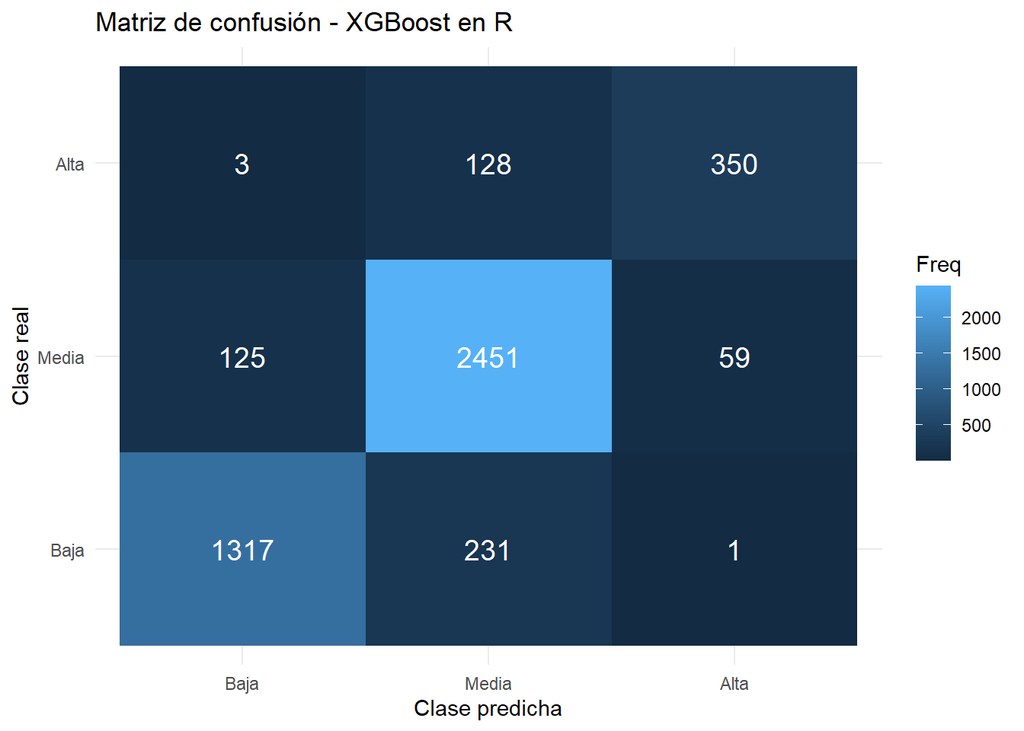

```r
cm_r <- table(Real = real_factor_r, Predicho = pred_factor_r)
cm_r_df <- as.data.frame(cm_r)

ggplot(cm_r_df, aes(x = Predicho, y = Real, fill = Freq)) +
  geom_tile() +
  geom_text(aes(label = Freq), color = "white", size = 5) +
  labs(
    title = "Matriz de confusión - XGBoost en R",
    x = "Clase predicha",
    y = "Clase real"
  ) +
  theme_minimal()
```

**Python**

**Mostrar código**

```python
from sklearn.metrics import confusion_matrix, classification_report, accuracy_score, log_loss

py_prob = xgb_basico_py.predict_proba(pyX_test)
py_pred_enc = np.argmax(py_prob, axis=1)
py_pred = le.inverse_transform(py_pred_enc)

print("Accuracy:", round(accuracy_score(pyy_test, py_pred), 4))
```

```
Accuracy: 0.9087
```

**Mostrar código**

```python
print("Log-loss:", round(log_loss(pyy_test_enc, py_prob), 4))
```

```
Log-loss: 0.2375
```

**Mostrar código**

```python
print(classification_report(pyy_test, py_pred))
```

```
              precision    recall  f1-score   support

        Alta       0.89      0.82      0.85       482
        Baja       0.93      0.88      0.90      1550
       Media       0.90      0.94      0.92      2635

    accuracy                           0.91      4667
   macro avg       0.91      0.88      0.89      4667
weighted avg       0.91      0.91      0.91      4667
```

**Mostrar código**

```python
import matplotlib.pyplot as plt
from sklearn.metrics import ConfusionMatrixDisplay

cm = confusion_matrix(pyy_test, py_pred, labels=le.classes_)
disp = ConfusionMatrixDisplay(confusion_matrix=cm, display_labels=le.classes_)
disp.plot(values_format="d")
```

```
<sklearn.metrics._plot.confusion_matrix.ConfusionMatrixDisplay object at 0x0000014F2CE6F690>
```

**Mostrar código**

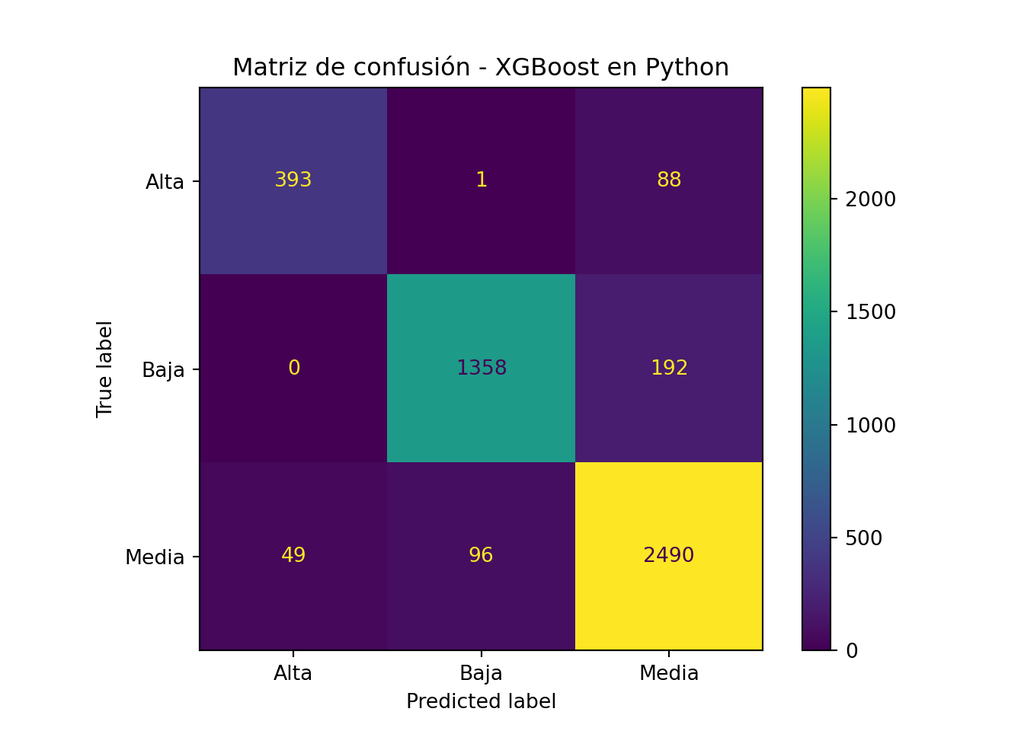

```python
plt.title("Matriz de confusión - XGBoost en Python")
plt.show()
```

# 10 Early stopping

Una de las ventajas prácticas de XGBoost es que permite usar **early stopping**. La idea es entrenar muchos árboles como máximo, pero detener el entrenamiento cuando el rendimiento en validación deja de mejorar.

Esto evita elegir manualmente el número exacto de árboles. Si el error de validación mejora hasta la ronda 87 y después empieza a empeorar, el modelo se queda con la mejor ronda encontrada.

**R**

**Mostrar código**

```r
set.seed(1994)

xgb_es <- xgb.train(
  params = params_basicos,
  data = dtrain,
  nrounds = 1000,
  watchlist = list(train = dtrain, test = dtest),
  early_stopping_rounds = 30,
  verbose = 1
)
```

```
Multiple eval metrics are present. Will use test_mlogloss for early stopping.
Will train until test_mlogloss hasn't improved in 30 rounds.
```

**Mostrar código**

```r
best_iteration <- xgb_es$best_iteration
best_score <- xgb_es$best_score

cat("Mejor iteración:", best_iteration, "\n")
```

```
Mejor iteración: 1000
```

**Mostrar código**

```r
cat("Mejor score:", best_score, "\n")
```

```
Mejor score: 0.2015338
```

**Mostrar código**

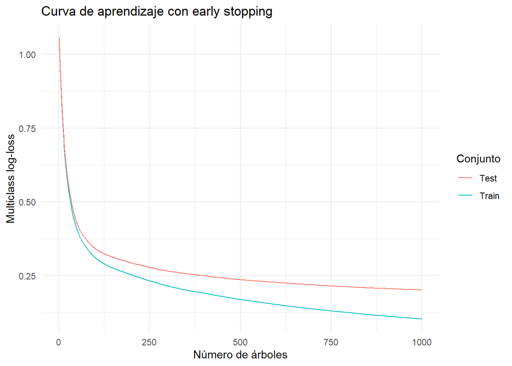

```r
eval_log <- xgb_es$evaluation_log

ggplot(eval_log, aes(x = iter)) +
  geom_line(aes(y = train_mlogloss, color = "Train")) +
  geom_line(aes(y = test_mlogloss, color = "Test")) +
  labs(
    title = "Curva de aprendizaje con early stopping",
    x = "Número de árboles",
    y = "Multiclass log-loss",
    color = "Conjunto"
  ) +
  theme_minimal()
```

**Python**

**Mostrar código**

```python
pyX_tr, pyX_val, pyy_tr, pyy_val = train_test_split(
    pyX_train,
    pyy_train_enc,
    test_size=0.2,
    random_state=1994,
    stratify=pyy_train_enc
)

xgb_es_py = XGBClassifier(
    objective="multi:softprob",
    num_class=len(le.classes_),
    n_estimators=1000,
    learning_rate=0.1,
    max_depth=4,
    subsample=0.8,
    colsample_bytree=0.8,
    reg_lambda=1,
    reg_alpha=0,
    eval_metric="mlogloss",
    random_state=1994,
    n_jobs=-1,
    early_stopping_rounds=30
)

try:
    xgb_es_py.fit(
        pyX_tr,
        pyy_tr,
        eval_set=[(pyX_tr, pyy_tr), (pyX_val, pyy_val)],
        verbose=False
    )
except TypeError:
    # Compatibilidad con versiones antiguas de xgboost.
    xgb_es_py.set_params(early_stopping_rounds=None)
    xgb_es_py.fit(
        pyX_tr,
        pyy_tr,
        eval_set=[(pyX_tr, pyy_tr), (pyX_val, pyy_val)],
        early_stopping_rounds=30,
        verbose=False
    )
```

```
XGBClassifier(base_score=None, booster=None, callbacks=None,
              colsample_bylevel=None, colsample_bynode=None,
              colsample_bytree=0.8, device=None, early_stopping_rounds=30,
              enable_categorical=False, eval_metric='mlogloss',
              feature_types=None, feature_weights=None, gamma=None,
              grow_policy=None, importance_type=None,
              interaction_constraints=None, learning_rate=0.1, max_bin=None,
              max_cat_threshold=None, max_cat_to_onehot=None,
              max_delta_step=None, max_depth=4, max_leaves=None,
              min_child_weight=None, missing=nan, monotone_constraints=None,
              multi_strategy=None, n_estimators=1000, n_jobs=-1, num_class=3, ...)
```

**Mostrar código**

```python
print("Mejor iteración:", getattr(xgb_es_py, "best_iteration", None))
```

```
Mejor iteración: 931
```

**Mostrar código**

```python
print("Mejor score:", getattr(xgb_es_py, "best_score", None))
```

```
Mejor score: 0.17749021158189618
```

**Mostrar código**

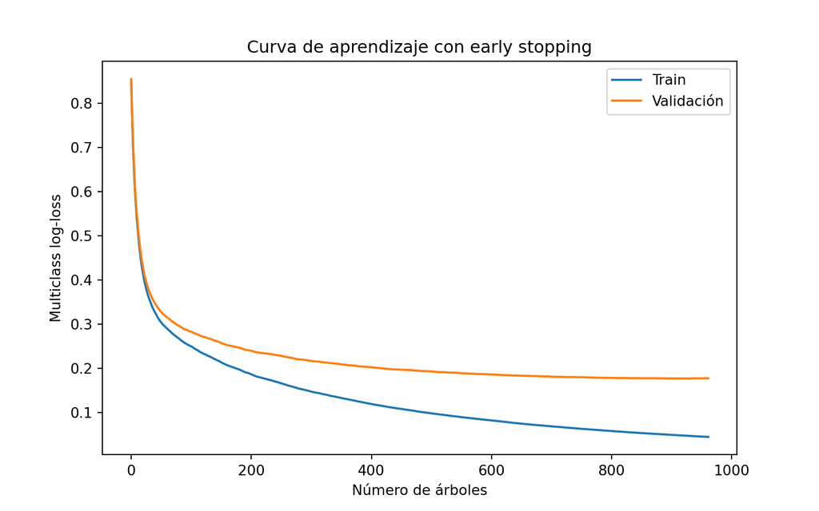

```python
results = xgb_es_py.evals_result()

plt.figure(figsize=(8, 5))
plt.plot(results["validation_0"]["mlogloss"], label="Train")
plt.plot(results["validation_1"]["mlogloss"], label="Validación")
plt.xlabel("Número de árboles")
plt.ylabel("Multiclass log-loss")
plt.title("Curva de aprendizaje con early stopping")
plt.legend()
plt.show()
```

# 11 Ajuste de hiperparámetros

XGBoost tiene muchos hiperparámetros. No conviene ajustarlos todos a la vez. Una estrategia razonable es empezar con los más influyentes:

- `max_depth`: controla la complejidad de cada árbol.
- `eta` / `learning_rate`: controla cuánto aporta cada árbol.
- `subsample`: introduce aleatoriedad en observaciones.
- `colsample_bytree`: introduce aleatoriedad en variables.
- `min_child_weight`: evita particiones con muy poca información.
- `gamma`: exige una mejora mínima para crear una nueva partición.

**R**

**Mostrar código**

```r
library(caret)
library(ggplot2)

head(modelLookup("xgbTree"), 4)
```

|  | model | parameter | label | forReg | forClass | probModel |
| --- | --- | --- | --- | --- | --- | --- |
| 1 | xgbTree | nrounds | # Boosting Iterations | TRUE | TRUE | TRUE |
| 2 | xgbTree | max_depth | Max Tree Depth | TRUE | TRUE | TRUE |
| 3 | xgbTree | eta | Shrinkage | TRUE | TRUE | TRUE |
| 4 | xgbTree | gamma | Minimum Loss Reduction | TRUE | TRUE | TRUE |

**Mostrar código**

```r
# se determina la semilla aleatoria
set.seed(101)

control <- trainControl(
  method = "cv",
  number = 10,
  classProbs = TRUE,
  summaryFunction = defaultSummary,
  savePredictions = "final",
  verboseIter = TRUE,
  allowParallel = FALSE
)

grid_xgb <- expand.grid(
  nrounds = c(100, 200),
  max_depth = c(3, 4),
  eta = c(0.05, 0.1),
  gamma = 0,
  colsample_bytree = 0.8,
  min_child_weight = 1,
  subsample = 0.8
)

# se entrena el modelo
xgb_caret <- train(
  RENTA ~ .,
  data = rtrain,
  method = "xgbTree",
  metric = "Accuracy",
  trControl = control,
  tuneGrid = grid_xgb
)
```

[output not shown]

[output cut: 26 more lines]

[output not shown]

**Mostrar código**

```r
xgb_caret
```

```
eXtreme Gradient Boosting

18669 samples
   35 predictor
    3 classes: 'Baja', 'Media', 'Alta'

No pre-processing
Resampling: Cross-Validated (10 fold)
Summary of sample sizes: 16802, 16803, 16801, 16801, 16803, 16802, ...
Resampling results across tuning parameters:

  eta   max_depth  nrounds  Accuracy   Kappa
  0.05  3          100      0.8636785  0.7499218
  0.05  3          200      0.8755696  0.7730645
  0.05  4          100      0.8781942  0.7775113
  0.05  4          200      0.8917459  0.8031123
  0.10  3          100      0.8762661  0.7744850
  0.10  3          200      0.8900854  0.8003064
  0.10  4          100      0.8900857  0.8001302
  0.10  4          200      0.9069582  0.8314550

Tuning parameter 'gamma' was held constant at a value of 0
Tuning

Tuning parameter 'min_child_weight' was held constant at a value of 1

Tuning parameter 'subsample' was held constant at a value of 0.8
Accuracy was used to select the optimal model using the largest value.
The final values used for the model were nrounds = 200, max_depth = 4, eta
 = 0.1, gamma = 0, colsample_bytree = 0.8, min_child_weight = 1 and subsample
 = 0.8.
```

**Mostrar código**

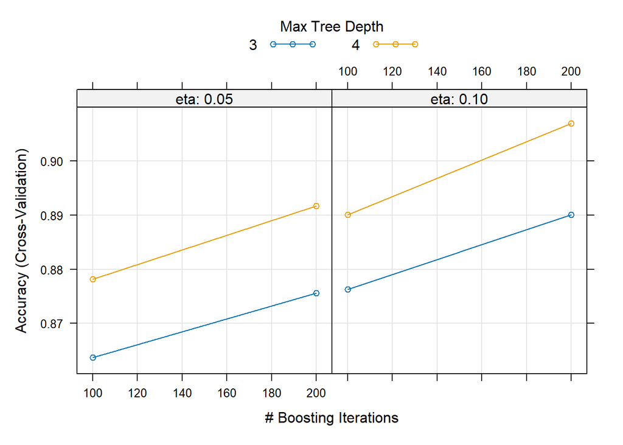

```r
plot(xgb_caret)
```

**Python**

**Mostrar código**

```python
from sklearn.model_selection import GridSearchCV, StratifiedKFold

param_grid = {
    "n_estimators": [100, 200],
    "max_depth": [3, 5],
    "learning_rate": [0.05, 0.1],
    "subsample": [0.8],
    "colsample_bytree": [0.8],
    "min_child_weight": [1, 5]
}

base_xgb = XGBClassifier(
    objective="multi:softprob",
    num_class=len(le.classes_),
    eval_metric="mlogloss",
    random_state=1994,
    n_jobs=-1
)

cv = StratifiedKFold(n_splits=3, shuffle=True, random_state=1994)

grid_search = GridSearchCV(
    estimator=base_xgb,
    param_grid=param_grid,
    scoring="accuracy",
    cv=cv,
    n_jobs=1,
    verbose=0
)

grid_search.fit(pyX_train, pyy_train_enc)
```

```
GridSearchCV(cv=StratifiedKFold(n_splits=3, random_state=1994, shuffle=True),
             estimator=XGBClassifier(base_score=None, booster=None,
                                     callbacks=None, colsample_bylevel=None,
                                     colsample_bynode=None,
                                     colsample_bytree=None, device=None,
                                     early_stopping_rounds=None,
                                     enable_categorical=False,
                                     eval_metric='mlogloss', feature_types=None,
                                     feature_weights=None, gamma=None,
                                     gr...
                                     max_delta_step=None, max_depth=None,
                                     max_leaves=None, min_child_weight=None,
                                     missing=nan, monotone_constraints=None,
                                     multi_strategy=None, n_estimators=None,
                                     n_jobs=-1, num_class=3, ...),
             n_jobs=1,
             param_grid={'colsample_bytree': [0.8],
                         'learning_rate': [0.05, 0.1], 'max_depth': [3, 5],
                         'min_child_weight': [1, 5], 'n_estimators': [100, 200],
                         'subsample': [0.8]},
             scoring='accuracy')
```

**Mostrar código**

```python
print(grid_search.best_params_)
```

```
{'colsample_bytree': 0.8, 'learning_rate': 0.1, 'max_depth': 5, 'min_child_weight': 1, 'n_estimators': 200, 'subsample': 0.8}
```

**Mostrar código**

```python
print(round(grid_search.best_score_, 4))
```

```
0.918
```

# 12 Importancia de variables

XGBoost ofrece varias formas de medir la importancia de variables. Las más habituales son:

- **Gain**: mejora media de la función objetivo al usar una variable en una partición. Suele ser la más informativa.
- **Cover**: cantidad media de observaciones afectadas por las particiones donde aparece una variable.
- **Frequency**: número de veces que una variable aparece en los árboles.

Es importante no confundir importancia con causalidad. Una variable puede ser importante porque está correlacionada con otras, porque segmenta bien los datos o porque captura diferencias espaciales/sociales, pero eso no significa necesariamente que cause directamente la renta.

**R**

**Mostrar código**

```r
importance_matrix <- xgb.importance(
  feature_names = colnames(x_train),
  model = xgb_es
)

head(importance_matrix, 20)
```

| Feature | Gain | Cover | Frequency |
| --- | --- | --- | --- |
| DISTANCE_TO_DIAGONAL | 0.228383967 | 0.165145283 | 0.167305579 |
| DISTANCE_TO_CITY_CENTER | 0.185505238 | 0.186938749 | 0.183041578 |
| CDISCiutat-Vella | 0.134436376 | 0.022246722 | 0.007881404 |
| CDISSarrià-Sant Gervasi | 0.082672692 | 0.030875109 | 0.013162480 |
| UNITPRICE | 0.053199552 | 0.068734157 | 0.073747420 |
| DISTANCE_TO_METRO | 0.047015957 | 0.104859388 | 0.120017157 |
| CDISEixample | 0.046870892 | 0.025517878 | 0.011232341 |
| CONSTRUCTEDAREA | 0.046795553 | 0.065675766 | 0.064874139 |
| CADDWELLINGCOUNT | 0.026415575 | 0.065235667 | 0.065195829 |
| CADCONSTRUCTIONYEAR | 0.023818909 | 0.056248349 | 0.065142214 |

[output cut: 10 more lines]

**Mostrar código**

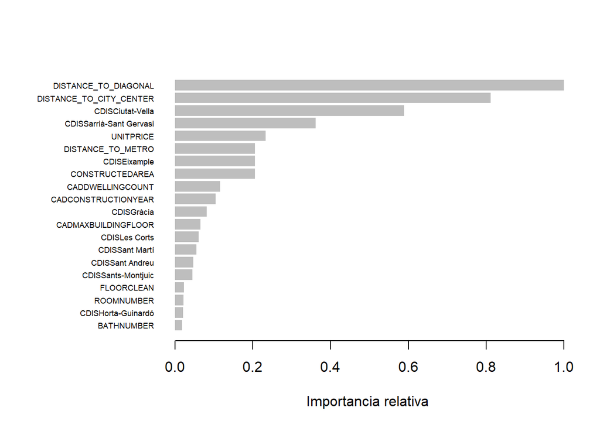

```r
xgb.plot.importance(
  importance_matrix = importance_matrix[1:20, ],
  measure = "Gain",
  rel_to_first = TRUE,
  xlab = "Importancia relativa"
)
```

**Mostrar código**

```r
importance_matrix %>%
  select(Feature, Gain, Cover, Frequency) %>%
  head(25)
```

| Feature | Gain | Cover | Frequency |
| --- | --- | --- | --- |
| DISTANCE_TO_DIAGONAL | 0.228383967 | 0.165145283 | 0.167305579 |
| DISTANCE_TO_CITY_CENTER | 0.185505238 | 0.186938749 | 0.183041578 |
| CDISCiutat-Vella | 0.134436376 | 0.022246722 | 0.007881404 |
| CDISSarrià-Sant Gervasi | 0.082672692 | 0.030875109 | 0.013162480 |
| UNITPRICE | 0.053199552 | 0.068734157 | 0.073747420 |
| DISTANCE_TO_METRO | 0.047015957 | 0.104859388 | 0.120017157 |
| CDISEixample | 0.046870892 | 0.025517878 | 0.011232341 |
| CONSTRUCTEDAREA | 0.046795553 | 0.065675766 | 0.064874139 |
| CADDWELLINGCOUNT | 0.026415575 | 0.065235667 | 0.065195829 |
| CADCONSTRUCTIONYEAR | 0.023818909 | 0.056248349 | 0.065142214 |

[output cut: 15 more lines]

**Python**

**Mostrar código**

```python
importances = xgb_es_py.feature_importances_
imp_df = pd.DataFrame({
    "variable": pyX_train.columns,
    "importance": importances
}).sort_values("importance", ascending=False)

imp_df.head(20)
```

```
                     variable  importance
58          CDIS_Ciutat-Vella    0.279222
67   CDIS_Sarrià-Sant Gervasi    0.109396
59              CDIS_Eixample    0.081883
62             CDIS_Les Corts    0.078071
64           CDIS_Sant Andreu    0.030104
60                CDIS_Gràcia    0.026238
66        CDIS_Sants-Montjuic    0.025621
11       DISTANCE_TO_DIAGONAL    0.022157
15                 HASLIFT_Si    0.018368
53    BUILTTYPEID_1_obraNueva    0.016740
65            CDIS_Sant Martí    0.015366
9     DISTANCE_TO_CITY_CENTER    0.015085
52  BUILTTYPEID_1_noObraNueva    0.011991
1             CONSTRUCTEDAREA    0.011572
63            CDIS_Nou Barris    0.010807
21         HASPARKINGSPACE_No    0.009931
61        CDIS_Horta-Guinardó    0.009152
14                 HASLIFT_No    0.008878
0                   UNITPRICE    0.008607
42               HASGARDEN_Si    0.007215
```

**Mostrar código**

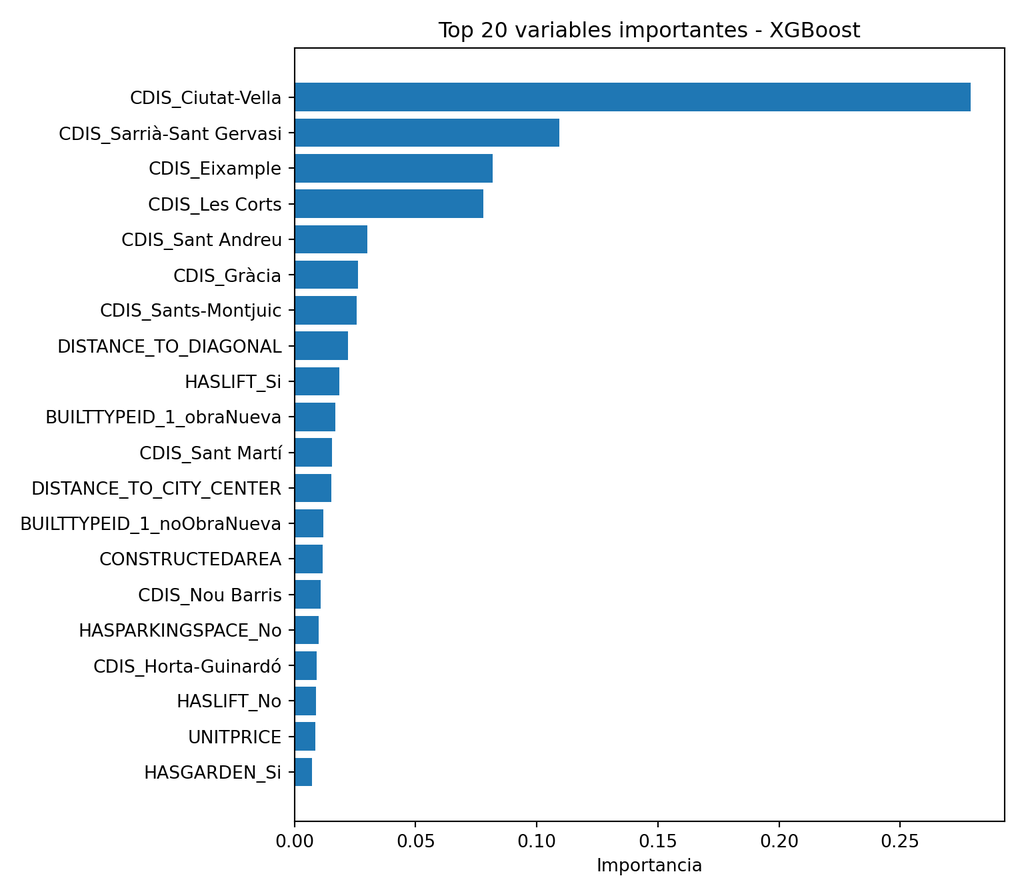

```python
top_imp = imp_df.head(20).sort_values("importance")

plt.figure(figsize=(8, 7))
plt.barh(top_imp["variable"], top_imp["importance"])
plt.xlabel("Importancia")
plt.title("Top 20 variables importantes - XGBoost")
plt.tight_layout()
plt.show()
```

**Mostrar código**

```python
booster = xgb_es_py.get_booster()

importance_gain = booster.get_score(importance_type="gain")
importance_cover = booster.get_score(importance_type="cover")
importance_weight = booster.get_score(importance_type="weight")

importance_types = pd.DataFrame({
    "variable": list(set(list(importance_gain.keys()) + list(importance_cover.keys()) + list(importance_weight.keys()))),
})

importance_types["gain"] = importance_types["variable"].map(importance_gain).fillna(0)
importance_types["cover"] = importance_types["variable"].map(importance_cover).fillna(0)
importance_types["frequency"] = importance_types["variable"].map(importance_weight).fillna(0)

importance_types.sort_values("gain", ascending=False).head(25)
```

```
                     variable       gain        cover  frequency
3           CDIS_Ciutat-Vella  62.091244  1270.649292      196.0
43   CDIS_Sarrià-Sant Gervasi  24.326723   714.562012      385.0
38              CDIS_Eixample  18.208601   885.470947      285.0
44             CDIS_Les Corts  17.360847   802.645020       96.0
22           CDIS_Sant Andreu   6.694213  1024.601318      187.0
67                CDIS_Gràcia   5.834681   659.574341      329.0
34        CDIS_Sants-Montjuic   5.697492   493.080597      228.0
52       DISTANCE_TO_DIAGONAL   4.927001   319.901276     5512.0
1                  HASLIFT_Si   4.084602   345.453644       43.0
23    BUILTTYPEID_1_obraNueva   3.722549   682.505737        7.0
28            CDIS_Sant Martí   3.417037   472.629456      347.0
57    DISTANCE_TO_CITY_CENTER   3.354484   368.880981     5945.0
40  BUILTTYPEID_1_noObraNueva   2.666445   728.496582       28.0
48            CONSTRUCTEDAREA   2.573203   323.895416     2727.0
35            CDIS_Nou Barris   2.403119   637.277588      208.0
55         HASPARKINGSPACE_No   2.208451   314.926422      112.0
58        CDIS_Horta-Guinardó   2.035254   399.593323      301.0
50                 HASLIFT_No   1.974228   251.977203      177.0
8                   UNITPRICE   1.914016   299.040985     3229.0
25               HASGARDEN_Si   1.604504   474.314331        8.0
60        CADMAXBUILDINGFLOOR   1.472515   262.913116     1441.0
46                 BATHNUMBER   1.449864   200.157806      284.0
54              HASDOORMAN_Si   1.437194   232.270035       29.0
2            CADDWELLINGCOUNT   1.403906   343.029053     2714.0
65               HASGARDEN_No   1.395046   396.002228       56.0
```

## 12.1 Interpretación de la matriz de importancia

La matriz de importancia debe leerse de forma comparativa:

- Una variable con alto `Gain` ha producido particiones muy útiles para reducir el error.
- Una variable con alto `Frequency` aparece muchas veces, pero no necesariamente es la más decisiva.
- Una variable con alto `Cover` afecta a muchas observaciones.

Ejemplo de lectura:

> Si `CDIS_Sarrià-Sant Gervasi` aparece con alto `Gain`, significa que pertenecer a ese distrito ayuda mucho al modelo a separar clases de renta. Si `DISTANCE_TO_CITY_CENTER` también aparece arriba, significa que la localización espacial tiene un papel fuerte en la predicción.

# 13 Extracción y visualización de uno de los árboles

Aunque XGBoost es un modelo de muchos árboles, se puede extraer un árbol individual. Esto sirve para entender una pequeña parte del ensamble, no todo el modelo completo.

Un árbol individual puede responder preguntas como:

- ¿Qué variable usa en la primera partición?
- ¿Qué umbrales aparecen?
- ¿Qué hojas finales genera?
- ¿Qué peso asigna a cada hoja?

**R**

**Mostrar código**

```r
arbol_1 <- xgb.model.dt.tree(
  feature_names = colnames(x_train),
  model = xgb_es,
  trees = 0
)

head(arbol_1, 20)
```

| Tree | Node | ID | Feature | Split | Yes | No | Missing | Quality | Cover |
| --- | --- | --- | --- | --- | --- | --- | --- | --- | --- |
| 0 | 0 | 0-0 | CDISEixample | 0.5000000 | 0-1 | 0-2 | 0-1 | 1.175925e+03 | 6701.777340 |
| 0 | 1 | 0-1 | DISTANCE_TO_CITY_CENTER | 1.9357197 | 0-3 | 0-4 | 0-3 | 1.774032e+03 | 5019.110840 |
| 0 | 2 | 0-2 | DISTANCE_TO_CITY_CENTER | 3.3227611 | 0-5 | 0-6 | 0-5 | 2.910522e+00 | 1682.666630 |
| 0 | 3 | 0-3 | DISTANCE_TO_CITY_CENTER | 0.4601694 | 0-7 | 0-8 | 0-7 | 2.361713e+02 | 1603.110960 |
| 0 | 4 | 0-4 | UNITPRICE | 2883.4843800 | 0-9 | 0-10 | 0-9 | 6.608675e+02 | 3415.999760 |
| 0 | 5 | 0-5 | DISTANCE_TO_CITY_CENTER | 1.9446487 | 0-11 | 0-12 | 0-11 | 1.238464e+00 | 1674.666630 |
| 0 | 6 | 0-6 | CADCONSTRUCTIONYEAR | 1966.0000000 | 0-13 | 0-14 | 0-13 | 6.107656e+00 | 8.000000 |
| 0 | 7 | 0-7 | CONSTRUCTEDAREA | 58.5000000 | 0-15 | 0-16 | 0-15 | 6.311031e+00 | 89.777771 |
| 0 | 8 | 0-8 | DISTANCE_TO_CITY_CENTER | 1.4890320 | 0-17 | 0-18 | 0-17 | 1.004063e+02 | 1513.333250 |
| 0 | 9 | 0-9 | DISTANCE_TO_CITY_CENTER | 4.0067768 | 0-19 | 0-20 | 0-19 | 1.560694e+02 | 881.333252 |

[output cut: 10 more lines]

**Mostrar código**

```r
if (requireNamespace("DiagrammeR", quietly = TRUE)) {
  xgb.plot.tree(
    feature_names = colnames(x_train),
    model = xgb_es,
    trees = 0
  )
} else {
  message("Para visualizar el árbol instala DiagrammeR: install.packages('DiagrammeR')")
}
```

[interactive chart not shown]

**Python**

**Mostrar código**

```python
# Estructura del primer árbol en formato texto
first_tree = booster.get_dump(with_stats=True)[0]
print(first_tree[:3000])
```

```
0:[CDIS_Sarrià-Sant Gervasi] yes=1,no=2,gain=2025.23767,cover=2207.95703
1:[CDIS_Les Corts] yes=3,no=4,gain=325.062866,cover=2039.89392
        3:[CONSTRUCTEDAREA<150] yes=7,no=8,missing=8,gain=146.500946,cover=1962.89575
            7:[UNITPRICE<5090.90918] yes=15,no=16,missing=16,gain=28.7746277,cover=1822.96655
                15:leaf=-0.0467793159,cover=1531.81763
                16:leaf=-0.0124339573,cover=291.148987
            8:[UNITPRICE<4842.10547] yes=17,no=18,missing=18,gain=86.5151062,cover=139.929199
                17:leaf=0.00847392622,cover=93.2861328
                18:leaf=0.174201354,cover=46.6430664
        4:[DISTANCE_TO_DIAGONAL<0.771498144] yes=9,no=10,missing=10,gain=143.103668,cover=76.9980774
            9:[DISTANCE_TO_CITY_CENTER<3.31402397] yes=19,no=20,missing=20,gain=43.5758667,cover=46.8281593
                19:leaf=0.175616786,cover=23.8768082
                20:leaf=0.38078782,cover=22.9513512
            10:[DISTANCE_TO_CITY_CENTER<4.17750406] yes=21,no=22,missing=22,gain=18.5333767,cover=30.1699219
                21:leaf=-0.0374330617,cover=23.8768082
                22:leaf=0.143853143,cover=6.29311228
    2:[CONSTRUCTEDAREA<158] yes=5,no=6,missing=6,gain=77.3605957,cover=168.063126
        5:[DISTANCE_TO_DIAGONAL<0.560042083] yes=11,no=12,missing=12,gain=42.3699951,cover=101.430161
            11:leaf=0.414218992,cover=18.6942463
            12:[DISTANCE_TO_CITY_CENTER<2.68860197] yes=23,no=24,missing=24,gain=45.3856201,cover=82.7359161
                23:leaf=0.0464185216,cover=11.2905836
                24:leaf=0.266637951,cover=71.4453354
        6:[DISTANCE_TO_METRO<0.0480681546] yes=13,no=14,missing=14,gain=3.00524902,cover=66.6329575
            13:[BATHNUMBER<3] yes=25,no=26,missing=26,gain=3.47111893,cover=2.59128165
                25:leaf=0.018044129,cover=1.11054921
                26:leaf=0.248895884,cover=1.48073232
            14:leaf=0.427871138,cover=64.0416718
```

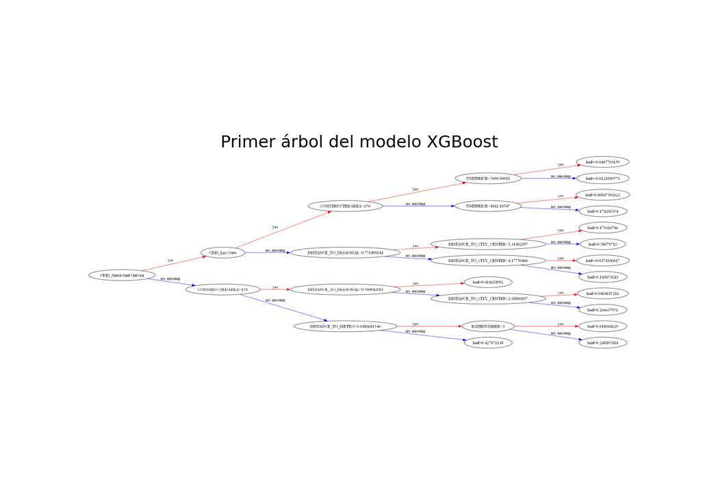

## 13.1 Cómo interpretar el árbol extraído

Un nodo interno tiene la forma:

$$\text{variable} < \text{umbral}$$

Si la condición se cumple, la observación va hacia una rama. Si no se cumple, va hacia la otra. Al final se llega a una hoja con un valor. En boosting, ese valor no es directamente una clase, sino una contribución parcial a la predicción final.

En clasificación multiclase, XGBoost suele construir árboles asociados a las clases. Por eso, un árbol aislado solo explica una parte concreta de la predicción. La predicción final combina muchos árboles.

# 14 Dependencia parcial

La **dependencia parcial** muestra cómo cambia la predicción media del modelo cuando una variable cambia y el resto de variables se mantiene según su distribución observada.

Esto ayuda a responder preguntas como:

> ¿Qué ocurre con la probabilidad de renta alta cuando aumenta la distancia al centro?

**R**

**Mostrar código**

[figure not shown]

```r
# Función de predicción robusta para PDP.
# El paquete pdp puede pasar newdata sin la variable objetivo.
# Como dummy_model_r fue entrenado con una fórmula RENTA ~ ., aquí añadimos
# una columna RENTA ficticia si no existe para evitar el error:
# "Variable(s) 'RENTA' are not in newdata".
pred_fun_alta <- function(object, newdata) {

  newdata <- as.data.frame(newdata)

  if (!"RENTA" %in% names(newdata)) {
    newdata$RENTA <- factor(clases[1], levels = clases)
  } else {
    newdata$RENTA <- factor(newdata$RENTA, levels = clases)
  }

  mat <- predict(dummy_model_r, newdata = newdata)
  mat <- as.matrix(mat)

  # Asegurar que las columnas tienen exactamente el mismo orden que en entrenamiento.
  columnas_faltantes <- setdiff(colnames(x_train), colnames(mat))
  if (length(columnas_faltantes) > 0) {
    faltantes <- matrix(
      0,
      nrow = nrow(mat),
      ncol = length(columnas_faltantes),
      dimnames = list(NULL, columnas_faltantes)
    )
    mat <- cbind(mat, faltantes)
  }

  mat <- mat[, colnames(x_train), drop = FALSE]

  pred <- predict(object, xgb.DMatrix(mat))
  pred <- matrix(pred, ncol = num_class, byrow = TRUE)
  pred[, which(clases == "Alta")]
}

pdp_alta <- pdp::partial(
  object = xgb_es,
  pred.var = "DISTANCE_TO_CITY_CENTER",
  train = rtrain,
  pred.fun = pred_fun_alta,
  grid.resolution = 20,
  progress = FALSE
)

plot(pdp_alta) +
  labs(
    title = "Dependencia parcial de DISTANCE_TO_CITY_CENTER",
    y = "Probabilidad media predicha de RENTA Alta"
  ) +
  theme_minimal()
```

**Python**

**Mostrar código**

```python
from sklearn.inspection import PartialDependenceDisplay

feature_name = "DISTANCE_TO_CITY_CENTER"
feature_index = list(pyX_train.columns).index(feature_name)

PartialDependenceDisplay.from_estimator(
    xgb_es_py,
    pyX_test,
    [feature_index],
    target=list(le.classes_).index("Alta")
)
```

```
<sklearn.inspection._plot.partial_dependence.PartialDependenceDisplay object at 0x0000014F2CFC5F90>
```

**Mostrar código**

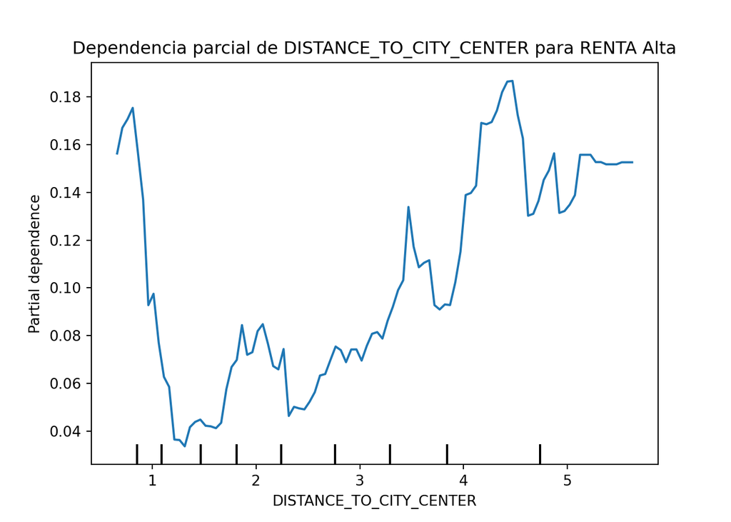

```python
plt.title("Dependencia parcial de DISTANCE_TO_CITY_CENTER para RENTA Alta")
plt.show()
```

# 15 Interpretación mediante SHAP values

## 15.1 Qué son los SHAP values

Los **SHAP values** son una herramienta de interpretabilidad basada en teoría de juegos. La idea es repartir la predicción de un modelo entre las variables explicativas.

Para una observación concreta, se puede escribir:

$$\text{predicción} = \text{valor base} + \sum_{j=1}^{p} \phi_j$$

donde:

- `valor base` es la predicción media del modelo;
- $\phi_j$ es la contribución de la variable $j$;
- una contribución positiva empuja la predicción hacia arriba;
- una contribución negativa empuja la predicción hacia abajo.

En clasificación multiclase, SHAP puede calcular contribuciones para cada clase. Por ejemplo, una variable puede aumentar la probabilidad de `Alta` y reducir la de `Baja`.

## 15.2 Por qué SHAP es especialmente útil en XGBoost

XGBoost suele tener un rendimiento alto, pero es difícil interpretar directamente cientos de árboles. SHAP permite obtener:

- interpretación global del modelo;
- ranking de variables relevantes;
- dirección del efecto de cada variable;
- explicación individual de una predicción;
- detección de relaciones no lineales.

**R**

**Mostrar código**

```r
# Para simplificar, se calculan SHAP values sobre una muestra.
set.seed(1994)
idx_shap <- sample(seq_len(nrow(x_test)), size = min(1000, nrow(x_test)))
X_shap_r <- x_test[idx_shap, ]

shap_values_r <- predict(
  xgb_es,
  X_shap_r,
  predcontrib = TRUE
)

# En multiclase, XGBoost devuelve contribuciones por clase.
dim(shap_values_r)
```

**Mostrar código**

```r
# SHAPforxgboost trabaja cómodamente en problemas binarios/regresión.
# En multiclase, según la versión de xgboost, predict(..., predcontrib = TRUE)
# puede devolver:
#   1) una matriz: observaciones x [clases * (variables + BIAS)]
#   2) un array 3D: observaciones x (variables + BIAS) x clases
# Este bloque soporta ambos formatos y evita errores de dimensiones.

feature_names_r <- colnames(x_train)
num_features <- length(feature_names_r) + 1 # +1 por BIAS

# Usamos la clase "Alta" si existe. Si no existe, usamos la última clase.
clase_alta_id <- match("Alta", clases)
if (is.na(clase_alta_id)) {
  clase_alta_id <- length(clases)
  message("No existe la clase 'Alta'. Se usa la clase: ", clases[clase_alta_id])
}

# Aseguramos formato numérico.
if (is.list(shap_values_r)) {
  # Algunas versiones devuelven lista por clase.
  shap_alta <- as.matrix(shap_values_r[[clase_alta_id]])
} else if (length(dim(shap_values_r)) == 3) {
  # Formato: observaciones x variables_con_bias x clases.
  shap_alta <- as.matrix(shap_values_r[, , clase_alta_id])
} else {
  # Formato matriz o vector.
  shap_values_mat <- as.matrix(shap_values_r)

  # Si solo hay una observación, as.matrix() puede dejar una sola columna.
  # Reparamos el caso vectorial cuando la longitud encaja con el número esperado.
  if (ncol(shap_values_mat) == 1 && length(shap_values_r) %% num_features == 0) {
    shap_values_mat <- matrix(
      as.numeric(shap_values_r),
      ncol = num_features * num_class,
      byrow = TRUE
    )
  }

  if (ncol(shap_values_mat) == num_features) {
    # Caso binario/regresión: ya viene un único bloque.
    shap_alta <- shap_values_mat
  } else {
    # Caso multiclase: extraemos el bloque de la clase seleccionada.
    cols_alta <- ((clase_alta_id - 1) * num_features + 1):(clase_alta_id * num_features)
    cols_alta <- cols_alta[cols_alta <= ncol(shap_values_mat)]
    shap_alta <- shap_values_mat[, cols_alta, drop = FALSE]
  }
}

# Normalizamos nombres de columnas.
if (ncol(shap_alta) >= num_features) {
  shap_alta <- shap_alta[, seq_len(num_features), drop = FALSE]
  colnames(shap_alta) <- c(feature_names_r, "BIAS")
} else if (ncol(shap_alta) == length(feature_names_r)) {
  colnames(shap_alta) <- feature_names_r
} else {
  stop("El objeto SHAP no tiene el número esperado de columnas. Revisa dim(shap_values_r).")
}

shap_feature_cols <- intersect(feature_names_r, colnames(shap_alta))

shap_long_alta <- shap_alta[, shap_feature_cols, drop = FALSE] %>%
  as.data.frame() %>%
  mutate(id = row_number()) %>%
  pivot_longer(-id, names_to = "variable", values_to = "shap")

shap_importance_alta <- shap_long_alta %>%
  group_by(variable) %>%
  summarise(mean_abs_shap = mean(abs(shap), na.rm = TRUE), .groups = "drop") %>%
  arrange(desc(mean_abs_shap))

head(shap_importance_alta, 20)
```

| variable | mean_abs_shap |
| --- | --- |
| DISTANCE_TO_DIAGONAL | 1.07764546 |
| CDISSarrià-Sant Gervasi | 0.58333333 |
| DISTANCE_TO_CITY_CENTER | 0.44215540 |
| CONSTRUCTEDAREA | 0.37985911 |
| CDISCiutat-Vella | 0.37179713 |
| CDISSants-Montjuic | 0.33484921 |
| UNITPRICE | 0.29250662 |
| CADCONSTRUCTIONYEAR | 0.25349543 |
| DISTANCE_TO_METRO | 0.23927924 |
| CDISHorta-Guinardó | 0.14736700 |

[output cut: 10 more lines]

**Mostrar código**

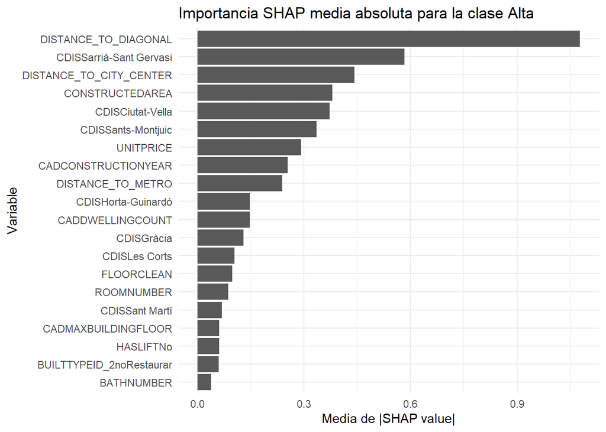

```r
shap_importance_alta %>%
  slice_head(n = 20) %>%
  mutate(variable = reorder(variable, mean_abs_shap)) %>%
  ggplot(aes(x = mean_abs_shap, y = variable)) +
  geom_col() +
  labs(
    title = "Importancia SHAP media absoluta para la clase Alta",
    x = "Media de |SHAP value|",
    y = "Variable"
  ) +
  theme_minimal()
```

**Mostrar código**

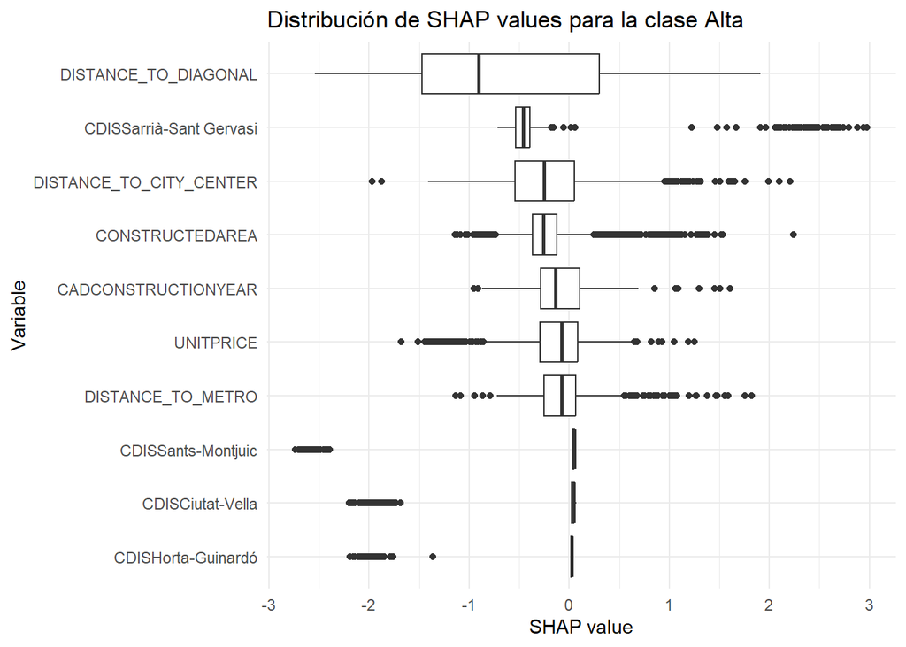

```r
top_vars_shap <- shap_importance_alta %>%
  slice_head(n = 10) %>%
  pull(variable)

shap_long_alta %>%
  filter(variable %in% top_vars_shap) %>%
  ggplot(aes(x = shap, y = reorder(variable, abs(shap), FUN = median))) +
  geom_boxplot() +
  labs(
    title = "Distribución de SHAP values para la clase Alta",
    x = "SHAP value",
    y = "Variable"
  ) +
  theme_minimal()
```

**Python**

**Mostrar código**

```python
import shap

# Muestra para evitar cálculos pesados
sample_shap = pyX_test.sample(n=min(1000, len(pyX_test)), random_state=1994)

explainer = shap.TreeExplainer(xgb_es_py)
shap_values = explainer.shap_values(sample_shap)

# Según la versión de shap/xgboost, puede devolver lista por clase o array 3D.
type(shap_values)
```

```
<class 'numpy.ndarray'>
```

**Mostrar código**

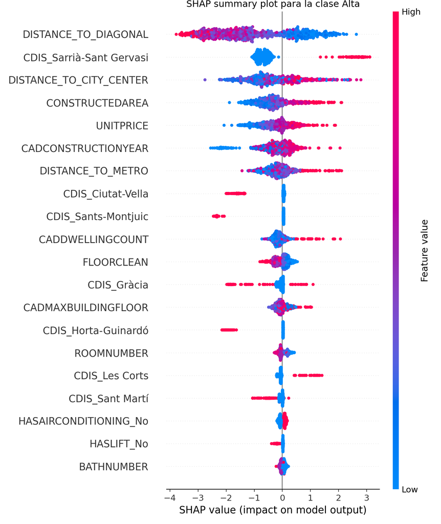

```python
class_alta_index = list(le.classes_).index("Alta")

if isinstance(shap_values, list):
    shap_alta_py = shap_values[class_alta_index]
else:
    # Formato frecuente: observaciones x variables x clases
    shap_alta_py = shap_values[:, :, class_alta_index]

shap.summary_plot(shap_alta_py, sample_shap, show=False)
plt.title("SHAP summary plot para la clase Alta")
plt.show()
```

**Mostrar código**

```python
mean_abs_shap = np.abs(shap_alta_py).mean(axis=0)
shap_importance_py = pd.DataFrame({
    "variable": sample_shap.columns,
    "mean_abs_shap": mean_abs_shap
}).sort_values("mean_abs_shap", ascending=False)

shap_importance_py.head(20)
```

```
                    variable  mean_abs_shap
11      DISTANCE_TO_DIAGONAL       1.510816
67  CDIS_Sarrià-Sant Gervasi       0.817281
9    DISTANCE_TO_CITY_CENTER       0.753988
1            CONSTRUCTEDAREA       0.547577
0                  UNITPRICE       0.453606
6        CADCONSTRUCTIONYEAR       0.410290
10         DISTANCE_TO_METRO       0.348730
58         CDIS_Ciutat-Vella       0.322575
66       CDIS_Sants-Montjuic       0.287443
8           CADDWELLINGCOUNT       0.199292
5                 FLOORCLEAN       0.178454
60               CDIS_Gràcia       0.160507
7        CADMAXBUILDINGFLOOR       0.155491
61       CDIS_Horta-Guinardó       0.150152
2                 ROOMNUMBER       0.114717
62            CDIS_Les Corts       0.108962
65           CDIS_Sant Martí       0.093565
16     HASAIRCONDITIONING_No       0.083400
14                HASLIFT_No       0.068099
3                 BATHNUMBER       0.057134
```

**Mostrar código**

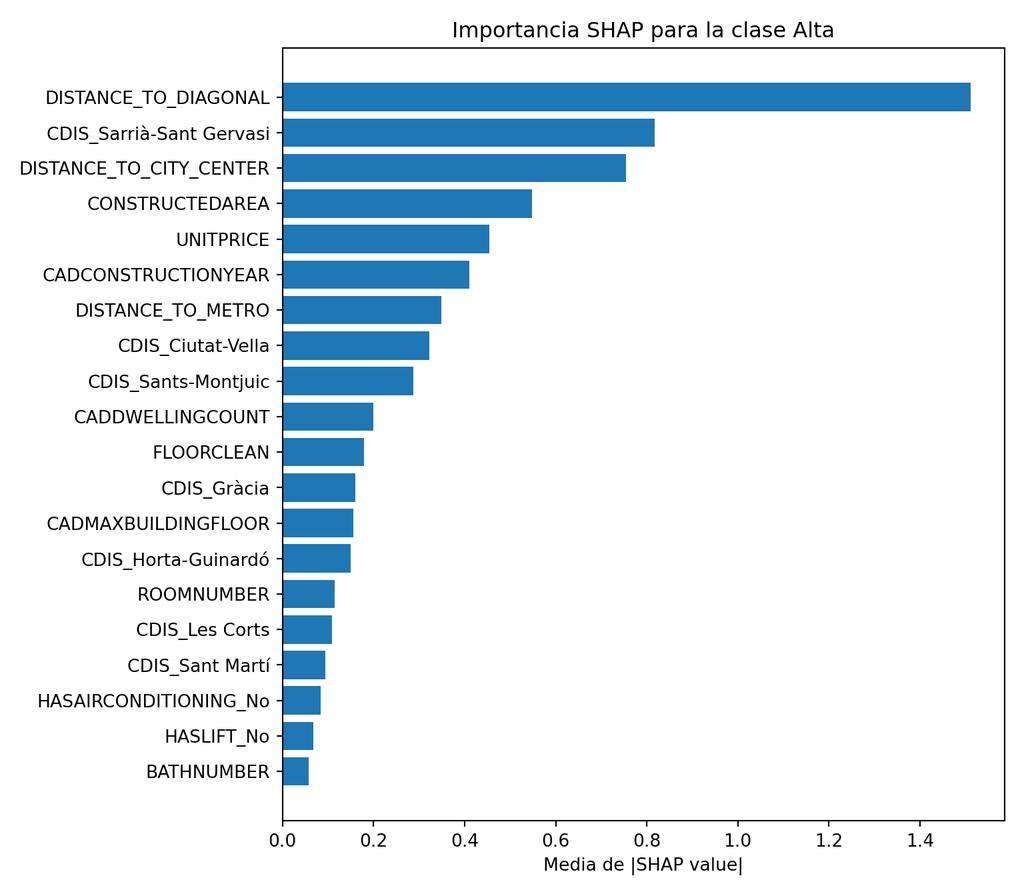

```python
top_shap = shap_importance_py.head(20).sort_values("mean_abs_shap")

plt.figure(figsize=(8, 7))
plt.barh(top_shap["variable"], top_shap["mean_abs_shap"])
plt.xlabel("Media de |SHAP value|")
plt.title("Importancia SHAP para la clase Alta")
plt.tight_layout()
plt.show()
```

**Mostrar código**

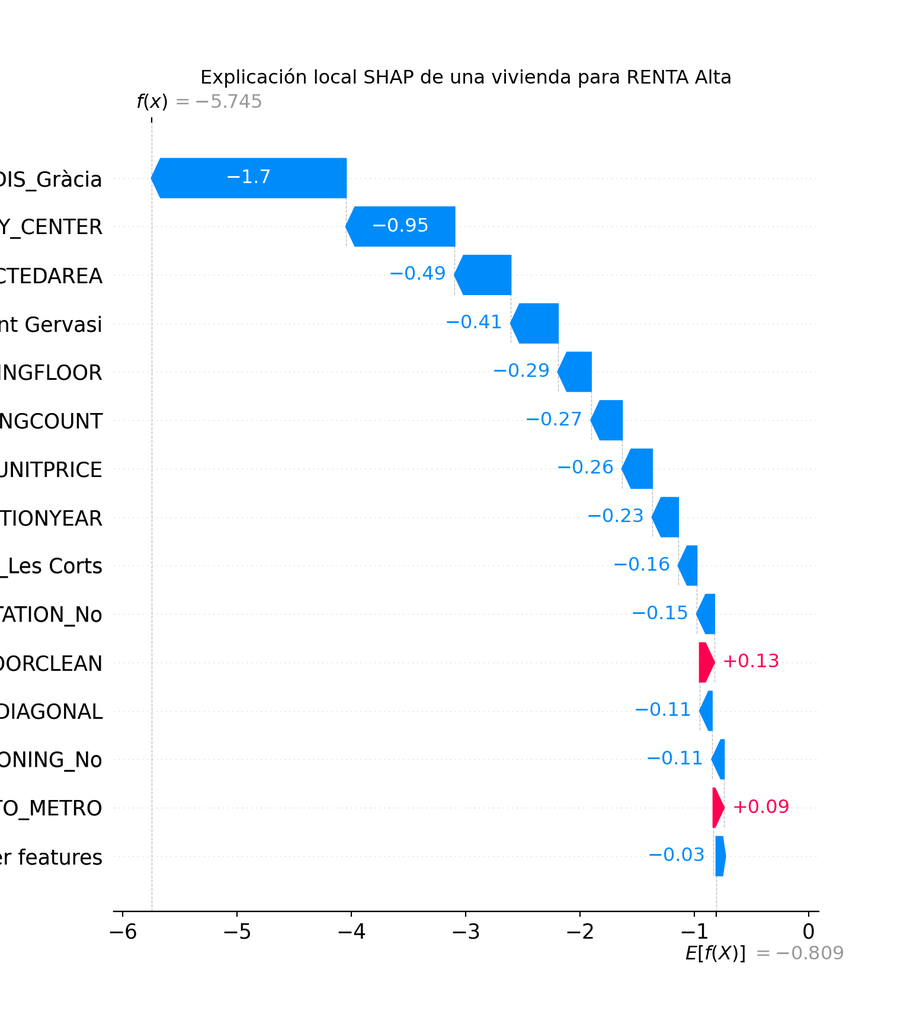

```python
# Explicación individual de una observación concreta.
obs_id = 0

expected_value = explainer.expected_value
if isinstance(expected_value, list):
    base_value = expected_value[class_alta_index]
elif isinstance(expected_value, np.ndarray):
    base_value = expected_value[class_alta_index] if expected_value.ndim == 1 else expected_value[0, class_alta_index]
else:
    base_value = expected_value

exp = shap.Explanation(
    values=shap_alta_py[obs_id],
    base_values=base_value,
    data=sample_shap.iloc[obs_id].values,
    feature_names=sample_shap.columns
)

shap.plots.waterfall(exp, max_display=15, show=False)
plt.title("Explicación local SHAP de una vivienda para RENTA Alta")
plt.show()
```

## 15.3 Cómo interpretar los gráficos SHAP

- eje vertical: variables ordenadas por importancia;
- eje horizontal: contribución SHAP;
- color: valor de la variable.

Lectura típica:

- valores SHAP positivos para la clase `Alta` empujan la predicción hacia `RENTA = Alta`;
- valores SHAP negativos para la clase `Alta` alejan la predicción de `RENTA = Alta`;
- si los puntos rojos de una variable aparecen a la derecha, valores altos de esa variable aumentan la probabilidad de renta alta;
- si aparecen a la izquierda, valores altos reducen la probabilidad de renta alta.

# 16 Comparación con un árbol individual

Para entender por qué XGBoost puede mejorar a un árbol simple, es útil recordar:

- un árbol individual aprende una única estructura de decisión;
- XGBoost aprende muchas estructuras pequeñas;
- cada árbol añade una corrección;
- el modelo final puede representar relaciones más complejas.

Sin embargo, esta mejora predictiva se paga con menor interpretabilidad directa. Por eso se combinan tres niveles de interpretación:

1. **Importancia de variables**: visión global rápida.
2. **Extracción de árboles**: visión estructural parcial.
3. **SHAP values**: explicación global y local de las predicciones.

# 17 Predicción sobre nuevas observaciones

Una vez entrenado el modelo, podemos generar predicciones sobre nuevas viviendas. En un caso real, esta parte se conectaría con un formulario, una API o una aplicación web.

**R**

**Mostrar código**

```r
# IMPORTANTE:
# dummy_model_r fue creado con la fórmula RENTA ~ .
# Por eso predict.dummyVars() exige que newdata tenga también la columna RENTA,
# aunque después esa columna NO se usa como predictor.

nuevo_registro <- rtest[1, , drop = FALSE]

# Función segura para transformar un único registro con dummyVars.
# Evita el error:
# "contrasts can be applied only to factors with 2 or more levels".
# La idea es añadir temporalmente una fila de referencia del entrenamiento para
# que model.matrix() vea todos los niveles categóricos necesarios.
predecir_dummies_seguro <- function(dummy_model, newdata, referencia_train, columnas_entrenamiento) {

  columnas_necesarias <- colnames(referencia_train)

  # Si falta alguna columna, se rellena con el valor de referencia del train.
  faltan <- setdiff(columnas_necesarias, colnames(newdata))
  if (length(faltan) > 0) {
    for (col in faltan) {
      newdata[[col]] <- referencia_train[[col]][1]
    }
  }

  newdata <- newdata[, columnas_necesarias, drop = FALSE]

  # Mantener exactamente los niveles/clases del entrenamiento.
  for (col in columnas_necesarias) {
    if (is.factor(referencia_train[[col]])) {
      newdata[[col]] <- factor(as.character(newdata[[col]]), levels = levels(referencia_train[[col]]))
    } else if (inherits(referencia_train[[col]], "Date")) {
      newdata[[col]] <- as.Date(newdata[[col]])
    } else if (is.numeric(referencia_train[[col]])) {
      newdata[[col]] <- as.numeric(newdata[[col]])
    } else if (is.integer(referencia_train[[col]])) {
      newdata[[col]] <- as.integer(newdata[[col]])
    } else {
      newdata[[col]] <- as.character(newdata[[col]])
    }
  }

  # Usamos TODO el train como referencia, no solo una fila.
  # Motivo: si una variable categórica tiene el mismo nivel en la fila de referencia
  # y en el nuevo registro, model.matrix() sigue viendo un único nivel y lanza:
  # "contrasts can be applied only to factors with 2 or more levels".
  # Al añadir todo el entrenamiento, cada factor conserva sus niveles reales.
  n_nuevo <- nrow(newdata)
  datos_tmp <- rbind(referencia_train, newdata)

  mat_tmp <- predict(dummy_model, newdata = datos_tmp)
  mat_tmp <- as.matrix(mat_tmp)

  # Nos quedamos solo con las últimas filas, que corresponden al nuevo registro.
  mat <- tail(mat_tmp, n_nuevo)
  mat <- as.matrix(mat)

  # Alinear columnas con x_train.
  columnas_faltantes <- setdiff(columnas_entrenamiento, colnames(mat))
  if (length(columnas_faltantes) > 0) {
    faltantes_mat <- matrix(0, nrow = nrow(mat), ncol = length(columnas_faltantes))
    colnames(faltantes_mat) <- columnas_faltantes
    mat <- cbind(mat, faltantes_mat)
  }

  columnas_extra <- setdiff(colnames(mat), columnas_entrenamiento)
  if (length(columnas_extra) > 0) {
    mat <- mat[, setdiff(colnames(mat), columnas_extra), drop = FALSE]
  }

  mat <- mat[, columnas_entrenamiento, drop = FALSE]
  return(mat)
}

nuevo_mat <- predecir_dummies_seguro(
  dummy_model = dummy_model_r,
  newdata = nuevo_registro,
  referencia_train = rtrain,
  columnas_entrenamiento = colnames(x_train)
)

nuevo_prob <- predict(xgb_es, xgboost::xgb.DMatrix(nuevo_mat))
nuevo_prob <- matrix(nuevo_prob, ncol = num_class, byrow = TRUE)
colnames(nuevo_prob) <- clases

nuevo_prob
```

```
         Baja      Media         Alta
[1,] 0.980497 0.01932397 0.0001790576
```

**Mostrar código**

```r
clases[which.max(nuevo_prob[1, ])]
```

```
[1] "Baja"
```

**Python**

**Mostrar código**

```python
nuevo_registro_py = pyX_test.iloc[[0]]
prob_nuevo_py = xgb_es_py.predict_proba(nuevo_registro_py)
pred_nuevo_py = le.inverse_transform(np.argmax(prob_nuevo_py, axis=1))

pd.DataFrame(prob_nuevo_py, columns=le.classes_)
```

```
       Alta      Baja     Media
0  0.007243  0.000922  0.991835
```

**Mostrar código**

```python
print("Clase predicha:", pred_nuevo_py[0])
```

```
Clase predicha: Media
```

# 18 Buenas prácticas al usar XGBoost

## 18.1 Evitar sobreajuste

Para reducir sobreajuste:

- usar `early_stopping_rounds`;
- reducir `max_depth`;
- reducir `learning_rate` y aumentar `n_estimators`;
- usar `subsample < 1`;
- usar `colsample_bytree < 1`;
- aumentar `lambda` o `alpha`;
- usar validación cruzada.

## 18.2 Evaluar con métricas adecuadas

Si las clases están desbalanceadas, la accuracy puede ser engañosa. En ese caso conviene mirar:

- macro F1;
- balanced accuracy;
- recall por clase;
- matriz de confusión;
- log-loss si importan las probabilidades.

## 18.3 Interpretar con cautela

Las importancias y SHAP values ayudan a entender el modelo, pero no demuestran causalidad. Si una variable como distrito aparece como muy relevante, puede estar actuando como proxy de renta, localización, calidad urbana, oferta inmobiliaria u otras variables no observadas.

# 19 Resumen final

En este documento se ha construido un flujo completo de XGBoost en R y Python:

1. carga y limpieza de datos;
2. creación de la variable objetivo `RENTA`;
3. codificación de variables categóricas;
4. partición train/test;
5. entrenamiento de XGBoost;
6. evaluación mediante matriz de confusión y métricas de clasificación;
7. uso de early stopping;
8. ajuste básico de hiperparámetros;
9. matriz de importancia de variables;
10. extracción de un árbol individual;
11. dependencia parcial;
12. interpretación mediante SHAP values;
13. predicción sobre nuevas observaciones.

La conclusión principal es que XGBoost es un modelo muy potente para datos tabulares, especialmente cuando existen relaciones no lineales e interacciones entre variables. No obstante, debe acompañarse siempre de validación, control del sobreajuste e interpretación rigurosa.

# 20 Bibliografía y recursos recomendados

- Chen, T., & Guestrin, C. (2016). *XGBoost: A Scalable Tree Boosting System*. Proceedings of the 22nd ACM SIGKDD International Conference on Knowledge Discovery and Data Mining.
- Friedman, J. H. (2001). *Greedy Function Approximation: A Gradient Boosting Machine*. Annals of Statistics.
- Lundberg, S. M., & Lee, S.-I. (2017). *A Unified Approach to Interpreting Model Predictions*. Advances in Neural Information Processing Systems.
- Documentación oficial de `xgboost` para R y Python.
- Documentación de `shap` para interpretación de modelos de árboles.

Aquesta web està creada por Dante Conti y Sergi Ramírez, (c) 2026